# Tutorial_1_Model calibration for rats

Wei-Chun Chou

June, 2020

# Introduction

This document gives you a simple tutorial to run the model calibration for the rat gestational and lactational PBPK model.

# Prerequisites

Before running your model, you should set up your working directory, compile the PBPK model, install all required packages and input needed datasets. The model file and datasets can be found in the additional files.

## Setting up your working directory

Before running, you should change your working directory to the **ModFit** folder. You can used two way to change your working directory as follow:

1. Use RStudio: use the menu to change your working directory under **Session > Set Working Directory > Choose Directory**.
2. Use R function: use the R function `setwd()` to change the path to your working directory.

## Loading required R package

The list of R packages should be installed first prior to the simulation. If you have not installed these packages (listed below), please install these packages to your Rstudio using the R function `require (" ")` and then use `library` to open it.

```r
library(mrgsolve)    ## R-package for Loading mrgsolve code
library(magrittr)    ## R-package for the pipe, %>% ,
library(dplyr)       ## R-package for transform and summarize tabular data with rows and columns; %>%
library(tidyverse)   ## R-package for transform and summarize tabular data with rows and columns; %>%
library(ggplot2)     ## R-package for GGplot
library(FME)         ## R-package for model fitting
library(minpack.lm)  ## R-package for model fitting
```

## Read mrgsolve-based PBPK Model R file

The rat pre-pregnant, gestational and lactational PBPK model were written in `RMod.R` file. Before compiling the model, please call this file using R function `source`.

```r
source (file = "RMod.R") ## input the rat gestational model
```

## Build mrgsolve-based PBPK Model

Read the code and build these mrgsolve-based PBPK models. You should make sure all models are built correctly.

```r
PreGmod_R <- mcode ("PreG_RatPBPK.code", PreG_RatPBPK.code) # bulid the pre-pregnant model
```

```
## Building PreG_RatPBPK_code ... done.
```

```r
Gmod_R <- mcode ("GRatPBPK.code", GRatPBPK.code) # bulid the gestational model
```

```
## Building GRatPBPK_code ... done.
```

```r
Lmod_R <- mcode ("LRatPBPK.code", LRatPBPK.code) # bulid the lactational model
```

```
## Building LRatPBPK_code ... done.
```

## Loading datasets for model calibration

In this step, you need to input the .csv file to the Rstudio. The function `read.csv` can be used to read the csv file into R

```r
Data_0 <- read.csv(file = "Data_R.csv")
```

# Model calibration for the gestational PBPK model

## Read these datasets and later used in model calibration

The data collected from Thibodeaux et al., 2003; doi: https://doi.org/10.1093/toxsci/kfg121  
Study design:

- Dose regimen: 1, 2, 3, 5, 10 mg/kg/day.
- Exposure duration: GD2 - GD20.
- Abreviation: maternal plasma (MP), maternal liver (ML), fetal liver (FL).

```r
## The datasets were filtered based on Study, Dose, Time
## and selected by the column of "Time" and "Conc".
OBS.A1  <- Data_0 %>% filter(Study == 1 & Sample == "MP" & Dose == 1 & Time != 0) %>% select(Time = "Time", CPlas = "Conc")
OBS.A2  <- Data_0 %>% filter(Study == 1 & Sample == "MP" & Dose == 2 & Time != 0) %>% select(Time = "Time", CPlas = "Conc")
OBS.A3  <- Data_0 %>% filter(Study == 1 & Sample == "MP" & Dose == 3 & Time != 0) %>% select(Time = "Time", CPlas = "Conc")
OBS.A4  <- Data_0 %>% filter(Study == 1 & Sample == "MP" & Dose == 5 & Time != 0) %>% select(Time = "Time", CPlas = "Conc")
OBS.A5  <- Data_0 %>% filter(Study == 1 & Sample == "MP" & Dose == 10& Time != 0) %>% select(Time = "Time", CPlas = "Conc")
OBS.A6  <- Data_0 %>% filter(Study == 1 & Sample == "ML" & Dose == 1 & Time != 0) %>% select(Time = "Time", CL    = "Conc")
OBS.A7  <- Data_0 %>% filter(Study == 1 & Sample == "ML" & Dose == 2 & Time != 0) %>% select(Time = "Time", CL    = "Conc")
OBS.A8  <- Data_0 %>% filter(Study == 1 & Sample == "ML" & Dose == 3 & Time != 0) %>% select(Time = "Time", CL    = "Conc")
OBS.A9  <- Data_0 %>% filter(Study == 1 & Sample == "ML" & Dose == 5 & Time != 0) %>% select(Time = "Time", CL    = "Conc")
OBS.A10 <- Data_0 %>% filter(Study == 1 & Sample == "ML" & Dose == 10 & Time!= 0) %>% select(Time = "Time", CL    = "Conc")
OBS.A11 <- Data_0 %>% filter(Study == 1 & Sample == "FL" & Dose == 1 & Time != 0) %>% select(Time = "Time", CFL   = "Conc")
OBS.A12 <- Data_0 %>% filter(Study == 1 & Sample == "FL" & Dose == 2 & Time != 0) %>% select(Time = "Time", CFL   = "Conc")
OBS.A13 <- Data_0 %>% filter(Study == 1 & Sample == "FL" & Dose == 3 & Time != 0) %>% select(Time = "Time", CFL   = "Conc")
OBS.A14 <- Data_0 %>% filter(Study == 1 & Sample == "FL" & Dose == 5 & Time != 0) %>% select(Time = "Time", CFL   = "Conc")
OBS.A15 <- Data_0 %>% filter(Study == 1 & Sample == "FL" & Dose == 10 & Time != 0)%>% select(Time = "Time", CFL   = "Conc")
```

## Define the prediction function for the gestational model calibration

Here, we define a prediction function to simulate the time-varying profiles of PFOS based on the study design of Thibodeaux et al., 2003. You can obtain the predicted values of maternal plasma (MP) and liver (ML), and fetal liver (FL) by running this prediction function.

```r
## Define the prediction function based on the study design of the literature of Thibodeaux et al., 2003
## Exposure scenario: Dosing druing pregnnacy from GD2 - GD20
pred.A <- function(Gpars, DOSE) { ## Gpars: input parameters, Dose: input dose,

    ## Get out of log domain
    Gpars <- exp(Gpars)                   ## Return a list of exp from log scale

    ## Exposure scenario for gestational exposure
    GBW          = 0.225                  ## Default value: 0.225-0.307 kg; Loccisano et al. (2012);
    tinterval    = 24                     ## Time interval;
    GTDOSE       = 20                     ## Total dosing/Dose times;
    GDOSE        = DOSE                   ## Input oral dose
    GDOSEoral    = GDOSE*GBW              ## Amount of oral dose

    ## To create a data set of 1 subject receiving DOSEoral every 24 hours
    Gex.oral <- ev (ID   = 1,             ## One individual
                    time = 24*2,          ## Dosing starts at GD2
                    amt  = GDOSEoral,     ## Amount of dose
                    ii   = tinterval,     ## Time interval
                    addl = GTDOSE - 1,    ## Addtional dosing
                    cmt  = "AST",         ## The dosing comaprtment: AST Stomach
                    tinf = 0.01,          ## Infusion time;
                    replicate = FALSE)    ## No replicate

    Gtsamp  = tgrid(0, tinterval*(GTDOSE - 1) + 24*2, 1) ## set up the output time; dtout = 1 hours

    ## Simulation of exposure scenaior
    Gout <-
    Gmod_R %>% ## Gestational PBPK model
    param (Gpars) %>% ## Update the parameter list with Gpars
    update(atol = 1E-6, maxsteps = 500000) %>%  ## Atol:tolerance parameter; maxsteps:maximum steps
    mrgsim_d (data = Gex.oral, tgrid = Gtsamp)

    ## Extract the "Time", "CPlas", "CL" and "CFL" from Gout;
    Goutdf = cbind.data.frame(Time   = Gout$time,      # Time : output time (hours)
                              CPlas  = Gout$Plasma,    # CPlas: PFOS concentration in maternal plasma
                              CL     = Gout$Liver,     # CL: PFOS concentration in maternal liver
                              CFL    = Gout$Liver_Fet) # CFL: PFOS concentration in fetal liver

    Goutdf <- Goutdf %>% filter (Time > 0)  # filter the value at time = 0
    return (Goutdf) # Return Goutdf
}
```

## Create a cost function for gestational model calibration

Define a cost function `Gcost` to estimate the model residual.  
The `modCost` function (from FME package) given a solution of a model and observed data, estimates the residuals, and the variable and model costs (sum of squared residuals).  
Note:

- `model`: model output; input the simulation value.
- `obs`: input the observed data.
- `cost`: if not NULL, the output of a previous call to modCost; in this case, the new output will combine both.

```r
Gcost<-function (pars){
    outdf.A1 <- pred.A (Gpars = pars,  DOSE = 1)
    outdf.A2 <- pred.A (Gpars = pars,  DOSE = 2)
    outdf.A3 <- pred.A (Gpars = pars,  DOSE = 3)
    outdf.A4 <- pred.A (Gpars = pars,  DOSE = 5)
    outdf.A5 <- pred.A (Gpars = pars,  DOSE = 10)

    cost<- modCost  (model = outdf.A1, obs = OBS.A1,  x ="Time")
    cost<- modCost  (model = outdf.A2, obs = OBS.A2,  x ="Time", cost = cost)
    cost<- modCost  (model = outdf.A3, obs = OBS.A3,  x ="Time", cost = cost)
    cost<- modCost  (model = outdf.A4, obs = OBS.A4,  x ="Time", cost = cost)
    cost<- modCost  (model = outdf.A5, obs = OBS.A5,  x ="Time", cost = cost)
    cost<- modCost  (model = outdf.A1, obs = OBS.A6,  x ="Time", cost = cost)
    cost<- modCost  (model = outdf.A2, obs = OBS.A7,  x ="Time", cost = cost)
    cost<- modCost  (model = outdf.A3, obs = OBS.A8,  x ="Time", cost = cost)
    cost<- modCost  (model = outdf.A4, obs = OBS.A9,  x ="Time", cost = cost)
    cost<- modCost  (model = outdf.A5, obs = OBS.A10, x ="Time", cost = cost)
    cost<- modCost  (model = outdf.A1, obs = OBS.A11, x ="Time", cost = cost)
    cost<- modCost  (model = outdf.A2, obs = OBS.A12, x ="Time", cost = cost)
    cost<- modCost  (model = outdf.A3, obs = OBS.A13, x ="Time", cost = cost)
    cost<- modCost  (model = outdf.A4, obs = OBS.A14, x ="Time", cost = cost)
    cost<- modCost  (model = outdf.A5, obs = OBS.A15, x ="Time", cost = cost)

    return(cost)
}
```

## List the initial parameters for later used in sensitivity analysis

```r
Gtheta.int <- log(c(
    Vmax_baso_invitro              = 393.45,
    Km_baso                        = 27.2,
    Vmax_apical_invitro            = 1808,
    Km_apical                      = 278,
    RAFbaso                        = 1.90,
    RAFapi                         = 4.15,
    Kdif                           = 5.1e-4,
    KeffluxC                       = 2.09,
    KbileC                         = 0.0026,
    KurineC                        = 1.60,
    Free                           = 0.022,
    PL                             = 3.66,
    PK                             = 0.8,
    PM                             = 0.16,
    PF                             = 0.13,
    PRest                          = 0.22,
    PPla                           = 0.41,
    K0C                            = 1,
    Kabsc                          = 2.12,
    KunabsC                        = 7.05e-5,
    Ktrans1C                       = 0.46,
    Ktrans2C                       = 1,
    Ktrans3C                       = 0.008,
    Ktrans4C                       = 0.001,
    Free_Fet                       = 0.022,
    PL_Fet                         = 3.66,
    PRest_Fet                      = 0.22
))
```

## Sensitivity function

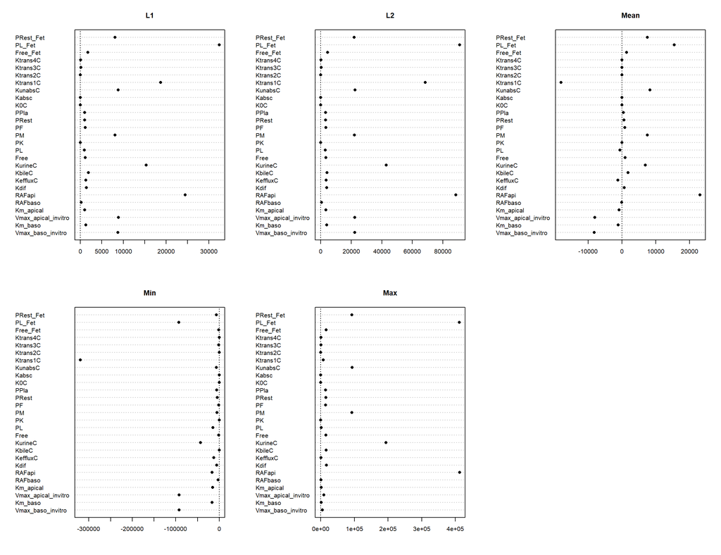

```r
## senFun is the sensitivity analysis function in FME
SnsPlasma <- sensFun(func = Gcost, parms = Gtheta.int, varscale = 1)
Sen       <- summary(SnsPlasma) ## summary the rsults of sensitivity analysis
plot(summary(SnsPlasma)) ## plot the results of sensitivity analysis
```

## Select sensitive parameters

```r
Gtheta <- Gtheta.int[abs(Sen$Mean) > 1.2*mean(abs(Sen$Mean))]
Gtheta
```

```
##   Vmax_baso_invitro Vmax_apical_invitro              RAFapi             KurineC
##           5.9749540           7.4999765           1.4231083           0.4700036
##                  PM             KunabsC            Ktrans1C              PL_Fet
##          -1.8325815          -9.5598978          -0.7765288           1.2974631
##           PRest_Fet
##          -1.5141277
```

## Select sensitive parameters and relevant parameters

Since the Levenberg-Marquardt-algorithm is a gradient-based optimization, the identification of a global optimum cannot be guaranteed. We hence selected the sensitive parameters and a few parameters that were relevant to calibrated datasets in order to obtain good initial guesses for the optimization.

```r
## Selected parameters
Gtheta <- log(c(
    Vmax_baso_invitro              = 393.45,
    #Km_baso                        = 27.2,
    #Vmax_apical_invitro            = 1808,
    Km_apical                      = 278,
    #RAFbaso                        = 1.90,
    #RAFapi                         = 4.15,
    #Kdif                           = 5.1e-4,
    #KeffluxC                       = 2.09,
    KbileC                         = 0.0026,
    #KurineC                        = 1.60,
    Free                           = 0.022,
    PL                             = 3.66,
    #PK                             = 0.8,
    #PM                             = 0.16,
    #PF                             = 0.13,
    #PRest                          = 0.22,
    #PPla                           = 0.41,
    #K0C                            = 1,
    #Kabsc                          = 2.12,
    #KunabsC                        = 7.05e-5,
    Ktrans1C                       = 0.46,
    #Ktrans2C                       = 1,
    Ktrans3C                       = 0.008,
    #Ktrans4C                       = 0.001,
    #Free_Fet                       = 0.022,
    PL_Fet                         = 3.66,
    PRest_Fet                      = 0.22
))
```

## Least squares fit using levenberg-marquart algorithm

The code `modFit` is the function fitting a model to data.  
The component of function:  
- `f`: a function to be minimized; here you need to input the cost function defined above.  
- `p`: initial values for the parameters to be optimized over.  
- `method`: fitting method; here we choose the levenberg-marquart algorithm (“Marq”).  
- `control`: additional control arguments - see details of nls.lm (“Marq”).

```r
GFit <- modFit(f = Gcost, p = Gtheta, method ="Marq",
               control = nls.lm.control(nprint = 1))
```

```
## It.    0, RSS = 1.95298e+06, Par. =    5.97495    5.62762   -5.95224   -3.81671    1.29746  -0.776529   -4.82831    1.29746   -1.51413
## It.    1, RSS =    73775.2, Par. =    6.26541    5.65894   -4.18243   -3.80955    1.24259   -0.68131   -7.16534    1.23617   -1.47805
## It.    2, RSS =    53561.7, Par. =    6.26401    5.70846    -4.5065   -3.79749    1.23082  -0.578912   -6.68953    1.23646   -1.42932
## It.    3, RSS =    49223.9, Par. =    6.26197     5.7066   -4.48086   -3.68346    1.24122  -0.578727   -7.48995    1.23645   -1.38637
## It.    4, RSS =    45121.4, Par. =    6.26637    5.68511     -4.441   -3.71963    1.24136  -0.578988   -9.03817    1.23564   -1.37574
## It.    5, RSS =    45119.7, Par. =    6.26636    5.68511   -4.44101   -3.71963    1.24136  -0.578988   -9.03822    1.23564   -1.37574
## It.    6, RSS =    45119.7, Par. =    6.26636    5.68511   -4.44101   -3.71963    1.24136  -0.578988   -9.03823    1.23564   -1.37574
## It.    7, RSS =    45119.7, Par. =    6.26636    5.68511   -4.44101   -3.71963    1.24136  -0.578988   -9.03823    1.23564   -1.37574
```

## Summary of fitting results

The model calibration has completed; Now you can check the fitting results and check the parameter values

```r
summary(GFit)    ## Summary of fitting results
```

```
##
## Parameters:
##                   Estimate Std. Error t value Pr(>|t|)
## Vmax_baso_invitro   6.2664     1.2182   5.144 9.80e-05 ***
## Km_apical           5.6851     1.2537   4.535 0.000338 ***
## KbileC             -4.4410     0.2332 -19.042 2.04e-12 ***
## Free               -3.7196     1.7382  -2.140 0.048113 *
## PL                  1.2414     0.1696   7.319 1.72e-06 ***
## Ktrans1C           -0.5790     0.2662  -2.175 0.044988 *
## Ktrans3C           -9.0382    20.1660  -0.448 0.660024
## PL_Fet              1.2356     0.4376   2.824 0.012226 *
## PRest_Fet          -1.3757     2.4760  -0.556 0.586158
## ---
## Signif. codes:  0 '***' 0.001 '**' 0.01 '*' 0.05 '.' 0.1 ' ' 1
##
## Residual standard error: 53.1 on 16 degrees of freedom
##
## Parameter correlation:
##                   Vmax_baso_invitro Km_apical    KbileC     Free       PL
## Vmax_baso_invitro           1.00000 -0.602153 -0.108524 -0.20159 -0.04903
## Km_apical                  -0.60215  1.000000 -0.008118 -0.07688 -0.19696
## KbileC                     -0.10852 -0.008118  1.000000  0.82805 -0.38208
## Free                       -0.20159 -0.076882  0.828048  1.00000 -0.40493
## PL                         -0.04903 -0.196960 -0.382081 -0.40493  1.00000
## Ktrans1C                   -0.24199  0.238674  0.541879  0.72913 -0.02168
## Ktrans3C                   -0.18941 -0.133289  0.868892  0.97808 -0.44975
## PL_Fet                      0.14776  0.235766 -0.870554 -0.95155  0.23669
## PRest_Fet                   0.03285  0.090744 -0.895126 -0.88536  0.63302
##                   Ktrans1C Ktrans3C  PL_Fet PRest_Fet
## Vmax_baso_invitro -0.24199  -0.1894  0.1478   0.03285
## Km_apical          0.23867  -0.1333  0.2358   0.09074
## KbileC             0.54188   0.8689 -0.8706  -0.89513
## Free               0.72913   0.9781 -0.9515  -0.88536
## PL                -0.02168  -0.4498  0.2367   0.63302
## Ktrans1C           1.00000   0.5994 -0.6099  -0.42154
## Ktrans3C           0.59944   1.0000 -0.9666  -0.93959
## PL_Fet            -0.60990  -0.9666  1.0000   0.88097
## PRest_Fet         -0.42154  -0.9396  0.8810   1.00000
```

```r
exp(GFit$par)    ## Converted the log-tranfromed parameters to arithmetic values
```

```
## Vmax_baso_invitro         Km_apical            KbileC              Free
##      5.265596e+02      2.944500e+02      1.178407e-02      2.424297e-02
##                PL          Ktrans1C          Ktrans3C            PL_Fet
##      3.460316e+00      5.604652e-01      1.187815e-04      3.440568e+00
##         PRest_Fet
##      2.526535e-01
```

## Check your results

```r
Gcost(GFit$par)
```

```
## $model
## [1] 45119.68
##
## $minlogp
## [1] Inf
##
## $var
##     name scale N SSR.unweighted SSR.unscaled          SSR
## 1    CFL     1 1   12997.385079 12997.385079 12997.385079
## 2    CFL     1 1    3146.626243  3146.626243  3146.626243
## 3    CFL     1 1     147.068371   147.068371   147.068371
## 4    CFL     1 1      18.019987    18.019987    18.019987
## 5    CFL     1 1       5.491377     5.491377     5.491377
## 6     CL     1 1       7.793382     7.793382     7.793382
## 7     CL     1 1    4671.809184  4671.809184  4671.809184
```

[output cut: 39 more lines]

# Model calibration for the lactational PBPK model

## Read these datasets and later used in model calibration

```r
## Read the data and later used in model calibration
## Filter the dataset and get the samples during lactation (Time > 480)
OBS.B1  <- Data_0 %>% filter(Study == 2 & Sample == "MP" & Dose == 1 )  %>% select(Time = "Time", CPlas = "Conc")%>%filter(Time > 480)
OBS.B2  <- Data_0 %>% filter(Study == 2 & Sample == "MP" & Dose == 0.3) %>% select(Time = "Time", CPlas = "Conc")%>%filter(Time > 480)
OBS.B3  <- Data_0 %>% filter(Study == 2 & Sample == "MP" & Dose == 0.1) %>% select(Time = "Time", CPlas = "Conc")%>%filter(Time > 480)
OBS.B4  <- Data_0 %>% filter(Study == 2 & Sample == "NP" & Dose == 1)   %>% select(Time = "Time", CPlas_pup = "Conc")%>%filter(Time > 480)
OBS.B5  <- Data_0 %>% filter(Study == 2 & Sample == "NP" & Dose == 0.3) %>% select(Time = "Time", CPlas_pup = "Conc")%>%filter(Time > 480)
OBS.B6  <- Data_0 %>% filter(Study == 2 & Sample == "NP" & Dose == 0.1) %>% select(Time = "Time", CPlas_pup = "Conc")%>%filter(Time > 480)
OBS.B7  <- Data_0 %>% filter(Study == 2 & Sample == "NL" & Dose == 1)   %>% select(Time = "Time", CL_pup = "Conc")%>%filter(Time > 480)
OBS.B8  <- Data_0 %>% filter(Study == 2 & Sample == "NL" & Dose == 0.3) %>% select(Time = "Time", CL_pup = "Conc")%>%filter(Time > 480)
OBS.B9  <- Data_0 %>% filter(Study == 2 & Sample == "NL" & Dose == 0.1) %>% select(Time = "Time", CL_pup = "Conc")%>%filter(Time > 480)
```

## Define the prediction function for the lactational model calibration

```r
## Exposure scenario B. Dosing from GD0 - PND20;
pred.B <- function(Lpars, DOSE) {

## Get out of log domain
Gpars <- lapply(GFit$par, exp)## Return a list of exp (parametrs for gestational model) from log scale
Lpars <- lapply(Lpars, exp) ## Return a list of exp (parametrs for lactational model) from log scale

## Exposure scenario for gestational exposure
GBW          = 0.225                  ## Default value: 0.225-0.307 from Loccisano et al. (2012);
tinterval    = 24                     ## Time interval;
GTDOSE       = 22                     ## Total dosing/Dose times; Repeat oral dose from GD0 - GD20
GDOSE        = DOSE                   ## Input oral dose
GDOSEoral    = GDOSE*GBW              ## Amount of oral dose

## To create a data set of 1 subject receiving DOSEoral every 24 hours
Gex.oral <- ev (ID   = 1,             ## One individual
                amt  = GDOSEoral,     ## Amount of dose
                ii   = tinterval,     ## Time interval
                addl = GTDOSE - 1,    ## Addtional dosing
                cmt  = "AST",         ## The dosing compartment: AST Stomach
                tinf = 0.01,          ## Infusion time;
                replicate = FALSE)    ## No replicate

Gtsamp  = tgrid(0, tinterval*(GTDOSE - 1) + 24*1, 1) ## set up the output time; dtout = 1 hours

## Simulation of exposure scenario during gestation (oral repeated dose to 0.1, 0.3, 1 mg/kg)
Gout <-
    Gmod_R %>%
    param (Gpars) %>%
    update(atol = 1E-6, maxsteps = 50000) %>%
    mrgsim_d (data = Gex.oral, tgrid = Gtsamp)

Goutdf = cbind.data.frame(Time      = Gout$time,       # Output time (hours)
                          CPlas     = Gout$Plasma,     # Maternal plasma
                          CL        = Gout$Liver,      # Maternal liver
                          CPlas_pup = Gout$Plasma_Fet, # Fetal plasma
                          CL_pup    = Gout$Liver_Fet)  # Fetal liver

# Extract the predicted values at GD21 and then used as initial values of the lactational model
Init <- Gout %>% filter (time == 21*24) %>%
        select(-c("AUC_CPlas","AUC_CPlas_Fet", "Plasma", "Liver", "Plasma_Fet", "Liver_Fet"))


## Exposure scenario for Lactational exposure; through PND0 - PND21 (end of lactation)
LBW          = 0.242                  ## Body weight; 0.242-0.292 from Loccisano et al. (2012);
tinterval    = 24                     ## Time interval;
LTDOSE       = 22                     ## Total dosing/Dose times; Repeated oral dose from PND0 - PND21
LDOSE        = DOSE                   ## Repeated oral dose (0.1, 0.3, 1 mg/kg);
LDOSEoral    = LDOSE*LBW              ## Amount of oral dose


# To create a data set of 1 subject receiving DOSEoral.A every 24 hours
Lex.oral <- ev (ID   = 1,            ## One individual
                amt  = LDOSEoral,    ## Amount of dose
                ii   = tinterval,    ## Time interval
                addl = LTDOSE - 1,   ## Addtional doseing
                cmt  = "AST",        ## The dosing comaprtment: AST Stomach
                tinf = 0.01,         ## Infusion time;
                replicate = FALSE)   ## No replicate

Ltsamp       = tgrid(0, tinterval*(LTDOSE - 1) + 24*2, 1) ## Simulation time from PND0 to PND21 with dosing of 1 + (LTDOSE - 1) + 2 days (No dosing)

## The concentration at the end of gestation used as initial concentration of lactation model
Lout <- Lmod_R %>%
        init(APlas_free = Init$APlas_free, APTC = Init$APTC, AFil = Init$AFil,
             AKb = Init$AKb, ARest = Init$ARest, AL = Init$AL, AM = Init$AM, AF = Init$AF,
             A_baso = Init$A_baso, A_apical = Init$A_apical, Adif = Init$Adif, Aefflux = Init$Aefflux,              APlas_free_pup = Init$APlas_Fet_free, AL_pup = Init$AL_Fet,
             ARest_pup = Init$ARest_Fet) %>%
        param (Lpars) %>%
        update(atol = 1E-6, maxsteps = 500000) %>%
        mrgsim_d (data = Lex.oral, tgrid = Ltsamp)

Loutdf = cbind.data.frame(Time   = Lout$time + 22*24,   # Simulation time + GD22 (22*24 hours)
                          CPlas  = Lout$Plasma,         # Maternal plasma
                          CL     = Lout$Liver,          # Maternal liver
                          CPlas_pup = Lout$Plasma_pup,  # Neonatal palsma
                          CL_pup    = Lout$Liver_pup)   # Neonatal liver

return (Loutdf)
}
```

## Create a cost function for lactational model calibration

Define a cost function `Lcost` to estimate the lactational model residual.

```r
## Estimate the model residual by modCost function
Lcost<-function (pars){
    outdf.A <- pred.B (Lpars = pars,  DOSE = 1)
    outdf.B <- pred.B (Lpars = pars,  DOSE = 0.3)
    outdf.C <- pred.B (Lpars = pars,  DOSE = 0.1)

    cost<- modCost  (model = outdf.A, obs = OBS.B1, x ="Time")
    cost<- modCost  (model = outdf.B, obs = OBS.B2, x ="Time", cost = cost)
    cost<- modCost  (model = outdf.C, obs = OBS.B3, x ="Time", cost = cost)
    cost<- modCost  (model = outdf.A, obs = OBS.B4, x ="Time", cost = cost)
    cost<- modCost  (model = outdf.B, obs = OBS.B5, x ="Time", cost = cost)
    cost<- modCost  (model = outdf.C, obs = OBS.B6, x ="Time", cost = cost)
    cost<- modCost  (model = outdf.A, obs = OBS.B7, x ="Time", cost = cost)
    cost<- modCost  (model = outdf.B, obs = OBS.B8, x ="Time", cost = cost)
    cost<- modCost  (model = outdf.C, obs = OBS.B9, x ="Time", cost = cost)

    return(cost)
}
```

## List the inital parameter for the later used in senstivity anlaiysis

All the values of parameters are initial values before optimization from Chou and Lin (2019) and Loccisano et al. (2012).

```r
## initial parmaeters for the lactational model
Ltheta.int <- log(c(
    Vmax_baso_invitro              = 393.45,
    Km_baso                        = 27.2,
    Vmax_apical_invitro            = 1808,
    Km_apical                      = 278,
    RAFbaso                        = 1.90,
    RAFapi                         = 4.15,
    KeffluxC                       = 2.09,
    KbileC                         = 0.0026,
    KurineC                        = 1.6,
    Free                           = 0.022,
    PL                             = 3.66,
    PK                             = 0.8,
    PM                             = 0.16,
    PF                             = 0.13,
    PRest                          = 0.26,
    PMilkM                         = 1.9,
    PMilkP                         = 0.11,
    PAMilkC                        = 0.5,
    K0C                            = 1,
    KabsC                          = 2.12,
    KunabsC                        = 7.05e-5,
    Kdif                           = 5.1e-4,
    KMilk0                         = 0.0268,
    Free_pup                       = 0.022,
    PL_pup                         = 3.66,
    PK_pup                         = 0.8,
    PRest_pup                      = 0.22,
    KabsC_pup                      = 2.12,
    KbileC_pup                     = 0.35,
    KurineC_pup                    = 1.6,
    KeffluxC_p                     = 2.09,
    Kdif_pup_0                     = 0.001,
    Vmax_baso_invitro_p            = 393.45,
    Km_baso_p                      = 27.2,
    Vmax_apical_invitro_p          = 1808,
    Km_apical_p                    = 278
))
```

## Sensivity analysis

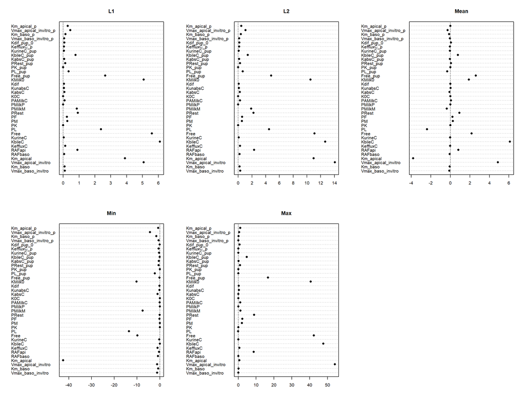

```r
SnsPlasma <- sensFun(func = Lcost, parms = Ltheta.int, varscale = 1)
Sen       <- summary(SnsPlasma)
plot(summary(SnsPlasma))
```

## Select senstive parameters;

```r
Ltheta <- Ltheta.int[abs(Sen$Min) > 1.5*mean(abs(Sen$Min))]
Ltheta
```

```
##             Km_apical                  Free                    PL
##             5.6276211            -3.8167128             1.2974631
##                PMilkM                KMilk0 Vmax_apical_invitro_p
##             0.6418539            -3.6193534             7.4999765
```

## Select senstive parameters and relavant parameters based on available data

```r
Ltheta <- log(c(
    #Vmax_baso_invitro              = 393.45,
    #Km_baso                        = 27.2,
    Vmax_apical_invitro            = 1808,
    #Km_apical                      = 278,
    #RAFbaso                        = 1.90,
    #RAFapi                         = 4.15,
    #KeffluxC                       = 2.09,
    #KbileC                         = 0.0026,
    #KurineC                        = 1.6,
    Free                           = 0.022,
    PL                             = 3.66,
    #PK                             = 0.8,
    #PM                             = 0.16,
    #PF                             = 0.13,
    PRest                          = 0.26,
    PMilkM                         = 1.9,
    #PMilkP                         = 0.11,
    #PAMilkC                        = 0.5,
    #K0C                            = 1,
    #KabsC                          = 2.12,
    #KunabsC                        = 7.05e-5,
    #Kdif                           = 5.1e-4,
    KMilk0                         = 0.0268,
    #Free_pup                       = 0.022,
    PL_pup                         = 3.66
    #PK_pup                         = 0.8,
    #PRest_pup                      = 0.22
    #KabsC_pup                      = 2.12,
    #KbileC_pup                     = 0.0026,
    #KurineC_pup                    = 1.6
    #KeffluxC_p                     = 2.09,
    #Kdif_pup_0                     = 0.001,
    #Vmax_baso_invitro_p            = 393.45,
    #Km_baso_p                      = 27.2,
    #Vmax_apical_invitro_p          = 1808
    #Km_apical_p                    = 278
))
```

## Least squares fit using levenberg-marquart algorithm

```r
LFit <- modFit(f = Lcost, p = Ltheta, method ="Marq",
               control = nls.lm.control(nprint = 1))
```

```
## It.    0, RSS =    1047.07, Par. =    7.49998   -3.81671    1.29746   -1.34707   0.641854   -3.61935    1.29746
## It.    1, RSS =    730.924, Par. =    7.66938   -4.21896    1.19494   -2.94177   -3.13129   0.265251    1.05421
## It.    2, RSS =    602.324, Par. =      7.082   -4.56343   0.820329   -2.39746   -4.92345    3.44379   0.903608
## It.    3, RSS =    174.977, Par. =    7.08019   -5.38172   0.823294   -2.24596   -4.21485    3.29943   0.850094
## It.    4, RSS =      174.7, Par. =    7.08036   -5.38219   0.825229   -2.24463   -4.21263    3.30185   0.849874
## It.    5, RSS =    173.615, Par. =    7.08031   -5.38229   0.825374    -2.2447   -4.21149    3.30447   0.850913
## It.    6, RSS =    171.323, Par. =    7.08031   -5.38229   0.825373    -2.2447   -4.20962    3.30982    0.85426
## It.    7, RSS =    170.144, Par. =    7.08031   -5.38229   0.825369    -2.2447   -4.21779    3.32084   0.857212
## It.    8, RSS =    169.503, Par. =     7.0803   -5.38227   0.825373    -2.2447   -4.21667    3.32148    0.85896
## It.    9, RSS =    168.653, Par. =    7.08029   -5.38225   0.825368    -2.2447    -4.2165    3.32151   0.863667
## It.   10, RSS =     167.67, Par. =    7.08032   -5.38212   0.825393    -2.2447   -4.21627    3.32156    0.87078
## It.   11, RSS =    167.679, Par. =    7.08032   -5.38212   0.825393    -2.2447   -4.21627    3.32156    0.87078
```

## Summary of fitting results

The model calibration has completed; Now you can check the fitting results and check the parameter values

```r
summary(LFit)    ## Summary of fitting results
```

```
##
## Parameters:
##                     Estimate Std. Error t value Pr(>|t|)
## Vmax_apical_invitro  7.08032    0.08333  84.963  < 2e-16 ***
## Free                -5.38212    0.28526 -18.867 9.98e-10 ***
## PL                   0.82539    0.28015   2.946 0.013298 *
## PRest               -2.24470    0.90715  -2.474 0.030877 *
## PMilkM              -4.21627    0.58731  -7.179 1.80e-05 ***
## KMilk0               3.32156    0.73356   4.528 0.000861 ***
## PL_pup               0.87078    0.17379   5.011 0.000396 ***
## ---
## Signif. codes:  0 '***' 0.001 '**' 0.01 '*' 0.05 '.' 0.1 ' ' 1
##
## Residual standard error: 3.904 on 11 degrees of freedom
##
## Parameter correlation:
##                     Vmax_apical_invitro    Free      PL    PRest    PMilkM
## Vmax_apical_invitro              1.0000 -0.6537 -0.1856 -0.31807 -0.833671
## Free                            -0.6537  1.0000 -0.5479  0.91782  0.262922
## PL                              -0.1856 -0.5479  1.0000 -0.77571  0.509856
## PRest                           -0.3181  0.9178 -0.7757  1.00000 -0.039266
## PMilkM                          -0.8337  0.2629  0.5099 -0.03927  1.000000
## KMilk0                           0.8871 -0.6173 -0.1110 -0.38401 -0.861888
## PL_pup                           0.3457 -0.6650  0.5081 -0.63384 -0.006416
##                      KMilk0    PL_pup
## Vmax_apical_invitro  0.8871  0.345725
## Free                -0.6173 -0.665028
## PL                  -0.1110  0.508070
## PRest               -0.3840 -0.633838
## PMilkM              -0.8619 -0.006416
## KMilk0               1.0000  0.154648
## PL_pup               0.1546  1.000000
```

```r
exp(LFit$par)    ## Converted the log-tranfromed parmaeters to arithmetic value
```

```
## Vmax_apical_invitro                Free                  PL               PRest
##        1.188349e+03        4.598087e-03        2.282778e+00        1.059598e-01
##              PMilkM              KMilk0              PL_pup
##        1.475363e-02        2.770345e+01        2.388774e+00
```

## Check your results

```r
Lcost(LFit$par)
```

```
## $model
## [1] 167.6703
##
## $minlogp
## [1] 100.376
##
## $var
##        name scale N SSR.unweighted SSR.unscaled        SSR
## 1    CL_pup     1 2     25.9805648   25.9805648 25.9805648
## 2    CL_pup     1 2     45.5529325   45.5529325 45.5529325
## 3    CL_pup     1 2     56.8502766   56.8502766 56.8502766
## 4 CPlas_pup     1 2      0.2956144    0.2956144  0.2956144
## 5 CPlas_pup     1 2      3.6628926    3.6628926  3.6628926
## 6 CPlas_pup     1 2     22.7649632   22.7649632 22.7649632
## 7     CPlas     1 2      0.2072251    0.2072251  0.2072251
```

[output cut: 26 more lines]

# Save results

You can use the function `saveRDS()`save the fitting results to RDS files.

```r
#saveRDS(GFit, file  ='GFit_rat.rds')    # Save the fitting results for gestational PBPK model
#saveRDS(LFit, file  ='LFit_rat.rds')   # Save the fitting results for lactational PBPK model
```